# 시민의 교양 - 세금

Jae Kwan Koo

# 세금

## tutorial

우리가 선택할 수 있는 사회의 방향성은 둘중 하나다.

- 1. 시장의 자유
- 2. 정부의 개입

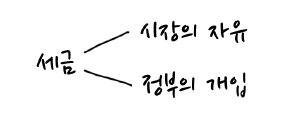

이 두 가지 방향성 중 하나를 선택하게 만드는 핵심적인 요인은 `세금`이다.  
세금은 사회 문제를 이해하기 위한 근원이다. 거칠게 말하면, 세금으로부터 모든 사회 문제가 비롯된다고도 할 수 있다.

국가의 다양한 문제 중에서 왜 하필이면 세금을 가장 근본적인 문제로 꼽는가?  
자본주의 사회에서는 모든 곳이 시장이다.

시장의 주체  
* `개인`  
* `기업`

- **정부!?**

이 외에 세 번째 주체가 있는데 정부다. 정부는 시장 밖에서 규제와 세금으로 끊임없이 시장에 개입하려고 한다. 규제를 위한 다양한 제도를 만들어 시장의 활동을 촉진하거나 제한한다. 그리고 세금을 거둬들여 정부의 재정을 확보한다. 따라서 시장과 정부는 사이가 좋을 수 없다.

- 시장의 자유 : 정부의 규제 완화와 세금 인하를 의미
- 정부의 개입 : 규제 강화와 세금 인상을 의미

이때 규제와 세금중 더 근본적인 것은 세금이다.  
세금과 복지의 관계는 일반적으로 비례한다.

### 중간정리

| type | content |
| --- | --- |
| 시장의 자유 | 세금 인하와 복지 축소를 의미 |
| 정부의 개입 | 세금 인상과 복지 확대를 의미 |

세금에 대한 선택은 `사회의 방향성`에 대한 선택이라고 할 수 있다. 세금이 중요한 이유이며 사회의 가장 근원적인 문제이다.

## 한국의 상황

B : 한국 상황에 대해 브리핑하자면,

- 2014년 OECD통계에 따르면 GDP대비 세율은 대략 24%
- OECD회원국의 평균비율은 34%입니다.  
  => 한국은 세금을 인상할 수 있는 여력이 충분하고도 남는다.
- 한국은 GDP대비 복지 지출은 대략 10%, 반면 OECD회원국의 평균비율은 21%입니다.  
  => 한국은 그들에 비해 절반의 복지도 시행하지 못하고 있다.

**결론적으로 한국은 낮은 세금 징수와 이에 따른 낮은 복지 지출로 빈부격차가 심화되었다.**

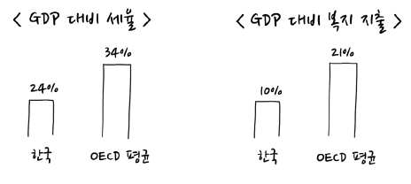

A : 한국 상황을 일부 선진국들하고만 비교하는 것은 무리

- OECD회원국과 한국은 성장해온 역사부터가 다르다. 그들은 수 세기 전에 근대화를 했고 앞선 산업화를 기반으로 아시아와 아프리카를 식민지로 만들어서 오랜 기간 착취했던 제국주의의 역사가 있다.
- 우리는 고작 반세기 동안 근대화가 이루어졌습니다. 따라서 OECD회원국 뿐만 아니라 개발도상국과도 비교해야 한다.

=> 우리와 경제성장의 역사가 비슷한 신흥경제지역인 대만, 홍콩, 싱가포르 등을 참고하면 한국의 세율이 낮지는 않다.

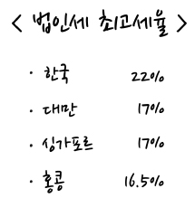

- 그 외에 미국과 일본 같은 선진국들도 세계적인 경제성장 둔화를 고려해, 높았던 법인세를 현재보다 낮추려는 움직임을 보이고 있다.
- 한국의 상황을 고려해볼 때, 세금 인상과 복지 강화는 현실적이지 않다.

**현실을 직시하자면, 우선 복지 지출을 줄이고 세금을 인하해서 국내 기업과 해외기업의 투자를 촉진하고, 개인의 노동의욕을 고취해야 합니다. 아직은 시장의 자유가 필요할 때.**

### 이 절을 마치면서..

현실을 객관적으로 파악하는 것은 원천적으로 불가능한 일인지도 모른다.  
실제로는 객관적인 자료들을 선별적으로 선택해서 이용할 수만 있을 뿐, 현실에 대한 해석은 항상 주관적인 것인지도 모른다.

| 전문가 | 접근법 | content |
| --- | --- | --- |
| A | 통시적인 측면에서 접근 | 시간적 변화를 고려해 한국의 상황을 파악하는 것이다. 과거로부터 성장해온 짧은 역사를 고려하고, 동시에 앞으로 성장 둔화가 심화될 미래를 반영한다. 성장의 과정 중에 있으므로 이에 맞는 정책이 필요하다는 입장 |
| B | 공시적인 측면에서 현재 한국의 상황을 파악 | 현재를 기준으로 다른 나라와의 세금 및 복지 현황을 비교하는 것이다. 유럽의 발전된 복지사회를 궁극적인 지향점으로 상정하고, 거기에 이르는 방향으로 현재 한국의 방향성을 결정해야 한다는 입장 |

## 누구의 세금을 높일 것인가?

일반적으로 증세의 주어가 명시되지 않을 때, 우리는 보통 그것이 부유층의 증세를 말한다고 자연스럽게 생각한다.

1. 우리가 세금에 대해 갖고 있는 일차적인 이미지가 ‘많이 벌수록 많이 내는 것’이기 때문이다 즉, 우리는 세금을 떠올릴 때 소득에 부과되는 직접세를 일차적으로 떠올린다.
2. 직접세가 소득이 높아질수록 세율도 함께 높아지는 누진세 제도를 따른다는 것을 우리가 이미 잘 알고 있기 때문이다. 즉, 우리는 많이 벌수록 부과되는 세금의 비율 자체가 늘어난다는 것을 알고 있다.

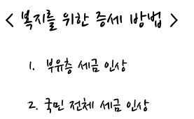

| 세금을 높여 복지를 확대하는 방법 |
| --- |
| 부유층의 세금을 높여서 사회전체의 복지 수준을 높이는 방법 |
| 국민 한 명당 세금을 일정하게 높여서 그것으로 복지를 실현하는 방법 |

정부나 특정 정당이 복지를 위한 증세를 말할 때, 특히 그 주어를 말하지 않을 때, `실제 주어`가 무엇인지 확인해야 한다.

### 부유층의 세금을 인상하는 방법 – 누진세

소득에 부과되는 세금에는 두 종류가 있다.

| type | content |
| --- | --- |
| `비례세` | 소득의 정로를 고려하지 않고 모두에게 동일한 세율을 부과 |
| `누진세` | 소득의 정도를 고려해서 고소득자일수록 높은 세율을 부과하는 방법 |

오늘날 비례세와 누진세에 대한 논쟁은 없고 누진세 기반으로 어느 정도의 누진율을 적용할 것인지가 국가마다의 주요 논쟁점이다.

근대산업화 이후 자본주의가 세계적으로 확대됨에 따라 빈부격차와 양극화가 심화되었다. 이를 해결하기 위해 정부가 시장에 적극적으로 개입한 결과가 누진세 제도다.

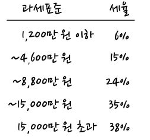

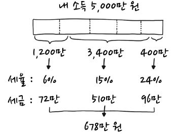

예컨대 연봉이 6000만 원인 사람X을 고려하면, 과세표준을 보니 3구간(4600~8800만 원)에 해당한다. 그럼 세금은 24%여야 한다. 이렇게 단순하게 적용되지 않는다.

6000만 원이 전부 내 소득이라고 할 수 없다. 만약 X가 국가로부터 인정받은 경비가 1000만 원이라면, 세금 부과의 대상이 되는 소득은 5000만 원이다.

이제 이 5000만원을 과세표준에 따라 누적으로 나눈다. 첫 구간은 1200까지, 2구간은 누적이 4600이되는 곳 까지… 이런 식으로 나누어 그 구간별로 세율을 매겨 세금을 계산한다.

현실에서의 세법은 더 다양한 조건들이 추가되어 매우 복잡하다. 책에서는 이번 생에서는 세금 산정 방법을 이해하는 것은 글렀다고 표현하고 있지만 문제될 것은 없다.  
세금과 복지의 현실에 대해 대략적인 큰 그림을 그려보는 것은 사회적 담론에 참여할 수 있는 최소한의 조건이 된다.

#### 실질적인 문제?

문제는 누진세를 적용하는가 하지 않는가가 아니다. 책정된 누진세율의 정도가 실제로 정당한지가 논쟁의 핵심이다. 누군가는 현재 누진세율이 정당하다고 하고 많은 사람들은 불만을 갖는다.

| type | content |
| --- | --- |
| 누진세 찬성 | 누진세가 경제적 양극화를 해결하는 가장 직접적인 방법. 빈부격차가 극단적으로 심화되고 있는 지금이 누진세를 강력하게 적용할 시점 |
| 누진세 반대 | 누진세는 국가가 소수의 고소득자들의 권리를 침해하는 제도이기 때문이다. |

## 부유층의 세금을 인상하는 방법 –부유세

`부유세` : 일정 수준 이상의 재산에 부과하는 세금 (소득 말고 재산)

예컨대 순자산이 100억인 사람이 있다고 할 때, 부유세가 매해 2%라면 10년이 지나면 재산은 1/5이 사라진다. 이런 이유로 부유층이 외국으로 이민가는 결과로 이어졌다.

<찬성>

- 부의 재분배
- 양극화를 없애고 빈부격차를 해소하자는 것

당장 현실에서 빈곤한 삶을 사는 다수의 사람들을 위해 사용하는 것이 사회적으로 더 큰 효용과 가치를 발생시킬 수 있다. 극단적으로 빈곤한 사람들이 존재하는 상황에서 사회 전체의 이익을 위해 이들의 재산을 제한하고 분산시킬 필요가 있다는 주장

<반대>

- 부유세의 실효성을 의심
- 현실적으로 부유세가 복지를 위한 재정 확보에 도움이 되지 않는다는 것

최상 위층의 개인과 기업이 세금이 낮은 국가로 이민을 가거나 재산을 이전하여 확보한 세금보다 국가에서 빠져나간 자본이 더 컸던 것이다.

- 또, 윤리적인 측면에서 비판받아왔다. 본질은 가난한 다수가 부유한 소수에게 느끼는 질투심과 열등감의 산물이라는 것

## 국민 전체의 세금을 인상하는 방법 – 간접세

부유층의 세금을 높이지 않으면서 국가 세금 수익을 높일 수 있다.  
**국민 전체의 세금을 동일하게 높이는 것이다.**

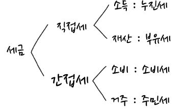

개인의 소득을 고려했을 때는 간접세가 공평하다고 말하기 어렵다.

예컨대, 모든 개인에게 주민세가 연 1만 원이라고 하면, 월 소득이 100만원인 W, 월 소득이 1600만원인 Z를 고려하자. 매해 1만원을 공평하게 납부하는 것 같지만, 사실은 소득을 고려하면 월 소득 대비 W는 1%, Z는 0.0625%를 세금으로 납부하는 것이다.

W가 느끼는 1만 원의 가치는 Z에게는 625원인 것이다.  
소득기준에서는 저소득자의 실질적인 부담을 증가시킨다는 면에서 `불평등한 세금`이다.

### 염려되는 부분

직접세와 간접세 중에서 어떤 것이 선이고 악인지는 없다. 당시의 국내외 상황을 고려해야 한다.  
시장 자유를 추구하는 정부는 시민들의 반발이 있기 직전까지 국민 전체의 세금을 인상한다.  
반대로 정부의 개입을 추구하는 정부는 부유층의 반발과 이탈이 있기 직전까지 직접세에 대한 증세를 밀어붙인다.

진짜 문제는 **움직이지 않는 시민**에게 있다. 상황이 악화되는 시점에 이르기까지 무엇이 문제인지 파악하지 못하는 부동의 시민들이 문제다.  
그들이 사회의 절대다수일 경우 그 사회는 균형을 잃어버리고 특정 계층, 특정 계급의 이익만을 반복적으로 보장하는 **부정한 사회**로 변질될 수 있다.

## 직접세와 간접세의 장단점

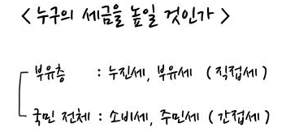

A : 래퍼곡선을 고려할 때, 직접세를 인상하면 안된다.

- 어느순간부터 세율이 늘어날수록 정부의 수입은 줄어든다.  
  국가가 내 모든 수입을 가져가면 일할 의욕이 없어지고 생산 활동을 하지 않을 것이기 때문이다.
- 또 세금을 회피할 수 있는 다른 국가로 이민을 갈 것이다.

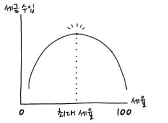

B : 래퍼곡선은 현실을 반영하지 못한다.

- 도대체 한국은 현재 어디 있는지 알 수가 없다.
- 2014년 세계 상위 소득 통계를 보면 상위 10%의 소득점유율이 프랑스는 32.69%인 데 반해 한국은 44.87%이다. 한국의 10%의 부유층이 전체 부의 절반 가까이를 독점하고 있는 것이다.

=> 따라서 한국은 아직 증세의 여력이 충분하며, 특히 직접세의 비중을 점진적으로 높여가야 한다는 것이다.

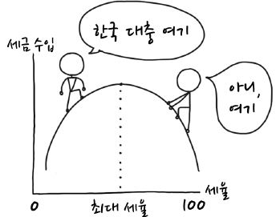

## 최종정리

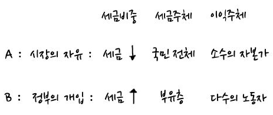